# Data Mining Project Part 1

Jake Harvey

2025-02-17

# 1.

## Electric Vehicle Population in Washington

| VIN..1.10. | County | City | State | Postal.Code | Model.Year | Make | Model | Electric.Vehicle.Type | Clean.Alternative.Fuel.Vehicle..CAFV..Eligibility | Electric.Range | Base.MSRP | Legislative.District | DOL.Vehicle.ID | Vehicle.Location | Electric.Utility | X2020.Census.Tract |
| --- | --- | --- | --- | --- | --- | --- | --- | --- | --- | --- | --- | --- | --- | --- | --- | --- |
| WBY8P4C55K | King | Bothell | WA | 98011 | 2019 | BMW | I3 | Plug-in Hybrid Electric Vehicle (PHEV) | Clean Alternative Fuel Vehicle Eligible | 126 | 0 | 1 | 249382416 | POINT (-122.20563 47.76144) | PUGET SOUND ENERGY INC\|\|CITY OF TACOMA - (WA) | 53033021804 |
| KNDCE3LG1K | Thurston | Olympia | WA | 98502 | 2019 | KIA | NIRO | Battery Electric Vehicle (BEV) | Clean Alternative Fuel Vehicle Eligible | 239 | 0 | 22 | 102638791 | POINT (-122.92333 47.03779) | PUGET SOUND ENERGY INC | 53067011100 |
| 5YJYGDEE8L | King | Seattle | WA | 98125 | 2020 | TESLA | MODEL Y | Battery Electric Vehicle (BEV) | Clean Alternative Fuel Vehicle Eligible | 291 | 0 | 46 | 112603774 | POINT (-122.30253 47.72656) | CITY OF SEATTLE - (WA)\|CITY OF TACOMA - (WA) | 53033000202 |
| 1N4AZ0CP0F | Thurston | Olympia | WA | 98506 | 2015 | NISSAN | LEAF | Battery Electric Vehicle (BEV) | Clean Alternative Fuel Vehicle Eligible | 84 | 0 | 22 | 187006893 | POINT (-122.87741 47.05997) | PUGET SOUND ENERGY INC | 53067010300 |
| WA1E2AFY8R | King | Seattle | WA | 98119 | 2024 | AUDI | Q5 E | Plug-in Hybrid Electric Vehicle (PHEV) | Not eligible due to low battery range | 23 | 0 | 36 | 271736741 | POINT (-122.3684 47.64586) | CITY OF SEATTLE - (WA)\|CITY OF TACOMA - (WA) | 53033006900 |
| WA1VAAGEXK | Kitsap | Silverdale | WA | 98383 | 2019 | AUDI | E-TRON | Battery Electric Vehicle (BEV) | Clean Alternative Fuel Vehicle Eligible | 204 | 0 | 23 | 272709076 | POINT (-122.69275 47.65171) | PUGET SOUND ENERGY INC | 53035091302 |

# 2.

## A.

I am going to use the Electric Range for this first part. While looking at this data I discovered that instead of NA they use 0 to show no information, so I will do the equations with 0’s included and excluded.

Excluding 0

| VIN..1.10. | County | City | State | Postal.Code | Model.Year | Make | Model | Electric.Vehicle.Type | Clean.Alternative.Fuel.Vehicle..CAFV..Eligibility | Electric.Range | Base.MSRP | Legislative.District | DOL.Vehicle.ID | Vehicle.Location | Electric.Utility | X2020.Census.Tract |
| --- | --- | --- | --- | --- | --- | --- | --- | --- | --- | --- | --- | --- | --- | --- | --- | --- |
| WBY8P4C55K | King | Bothell | WA | 98011 | 2019 | BMW | I3 | Plug-in Hybrid Electric Vehicle (PHEV) | Clean Alternative Fuel Vehicle Eligible | 126 | 0 | 1 | 249382416 | POINT (-122.20563 47.76144) | PUGET SOUND ENERGY INC\|\|CITY OF TACOMA - (WA) | 53033021804 |
| KNDCE3LG1K | Thurston | Olympia | WA | 98502 | 2019 | KIA | NIRO | Battery Electric Vehicle (BEV) | Clean Alternative Fuel Vehicle Eligible | 239 | 0 | 22 | 102638791 | POINT (-122.92333 47.03779) | PUGET SOUND ENERGY INC | 53067011100 |
| 5YJYGDEE8L | King | Seattle | WA | 98125 | 2020 | TESLA | MODEL Y | Battery Electric Vehicle (BEV) | Clean Alternative Fuel Vehicle Eligible | 291 | 0 | 46 | 112603774 | POINT (-122.30253 47.72656) | CITY OF SEATTLE - (WA)\|CITY OF TACOMA - (WA) | 53033000202 |
| 1N4AZ0CP0F | Thurston | Olympia | WA | 98506 | 2015 | NISSAN | LEAF | Battery Electric Vehicle (BEV) | Clean Alternative Fuel Vehicle Eligible | 84 | 0 | 22 | 187006893 | POINT (-122.87741 47.05997) | PUGET SOUND ENERGY INC | 53067010300 |
| WA1E2AFY8R | King | Seattle | WA | 98119 | 2024 | AUDI | Q5 E | Plug-in Hybrid Electric Vehicle (PHEV) | Not eligible due to low battery range | 23 | 0 | 36 | 271736741 | POINT (-122.3684 47.64586) | CITY OF SEATTLE - (WA)\|CITY OF TACOMA - (WA) | 53033006900 |
| WA1VAAGEXK | Kitsap | Silverdale | WA | 98383 | 2019 | AUDI | E-TRON | Battery Electric Vehicle (BEV) | Clean Alternative Fuel Vehicle Eligible | 204 | 0 | 23 | 272709076 | POINT (-122.69275 47.65171) | PUGET SOUND ENERGY INC | 53035091302 |

### Mean

With 0

```
## [1] 47.73619
```

With the amount of zeros that are in this dataset, it is no wonder that the mean is this low.

Without 0

```
## [1] 114.3081
```

Now that the zeros are gone, a more reasonable mean remains. The ranges are not even, with the majority of them falling below 100 miles. It is still able to overcome 100 with the remaining cars that are above it.

### Standard Deviation

With 0

```
## [1] 84.98714
```

The standard deviation is a decent range, especially because of the amount of zeros that are in this set. When you think about how far electric vehicles have come from the beginning, it makes sense that the more we advance, the longer the range will be.

Without 0

```
## [1] 98.41707
```

This seems like a more reasonable answer, because all of the zeros are out of the equation.

### Five Number Summary

With 0

```
## [1]   0   0   0  39 337
```

The five number summary is right for this dataset, but it only shows 0, 39, and 337.

Without 0

```
## [1]   6  30  73 215 337
```

This is a more reasonable response, but because we are using the data without zeros the first number is 6 instead of 0.

### Histogram

With 0

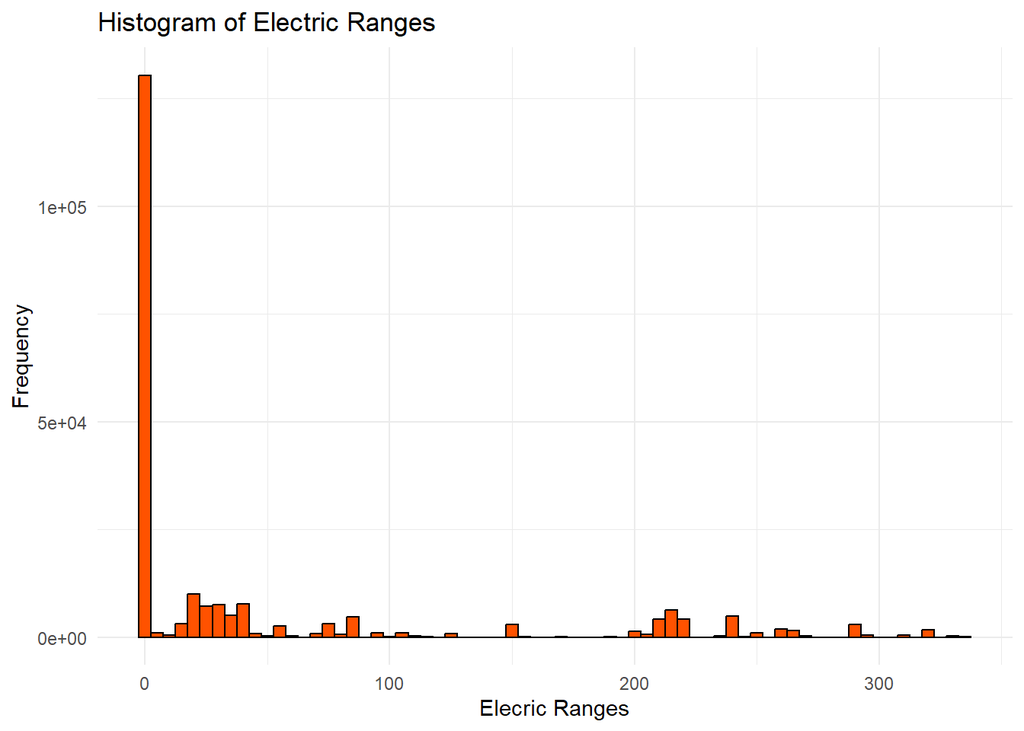

Yeah, I was unsure how many zeros were in this, but this just goes to show the difference in information.

Without 0

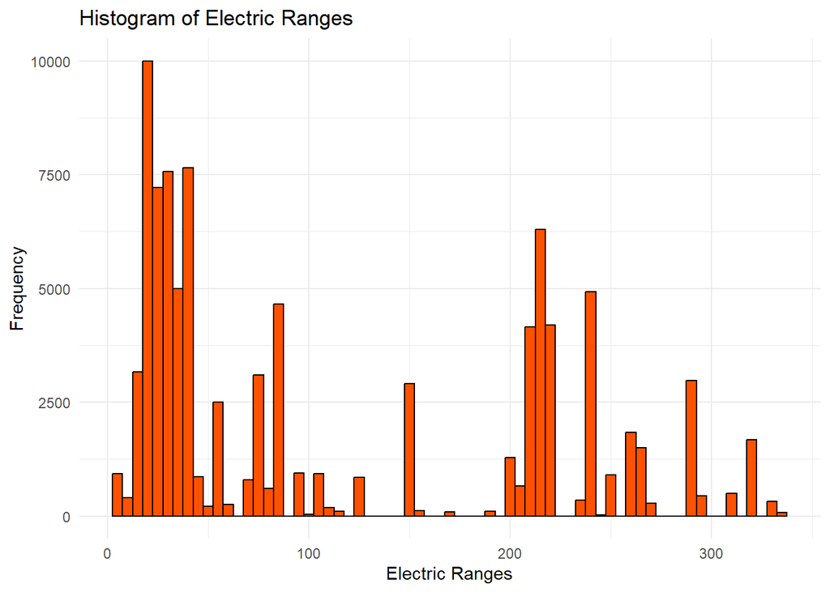

### Box Plot

With 0

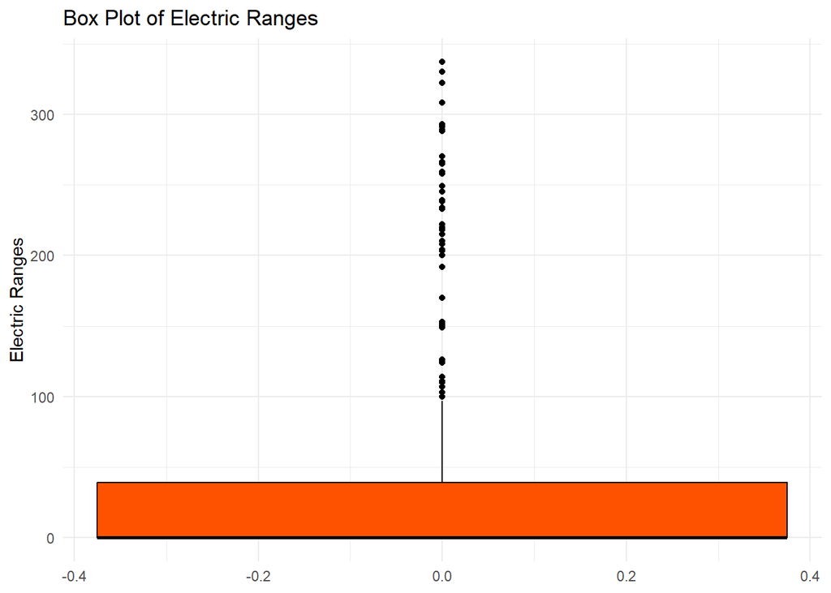

Without 0

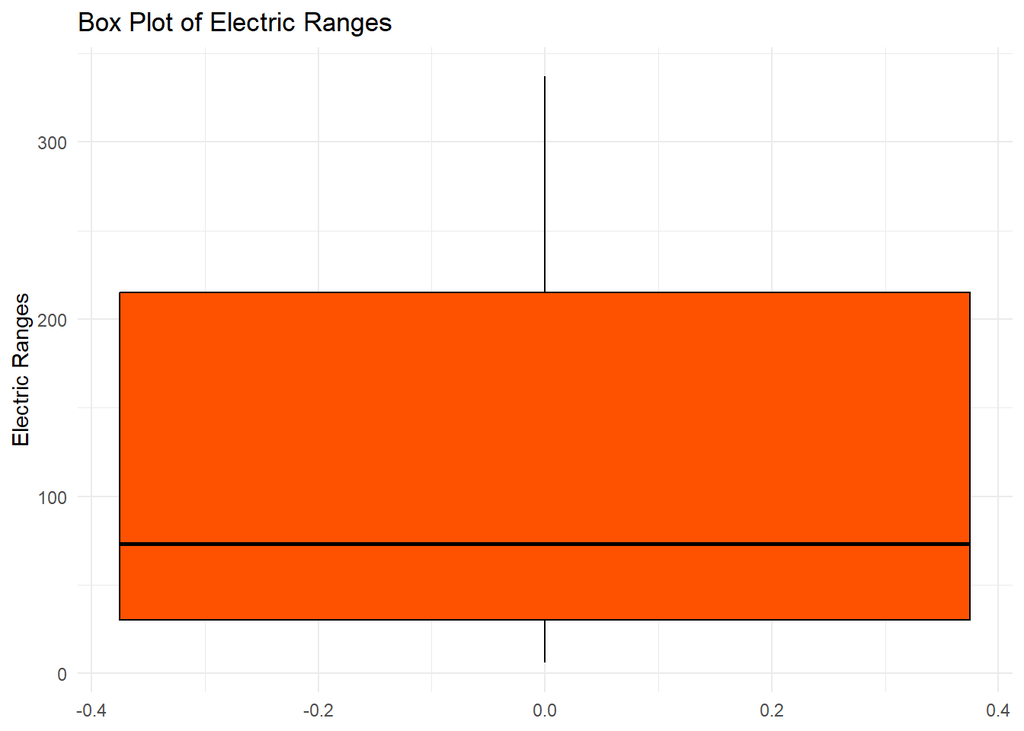

This box plot is more reasonable, but I feel like some information is missing because I believe that there are some entries that reach the 300s, and they should be outliers.

## B.

With 0

```r
cc <- cor(df$Model.Year, df$Electric.Range)

print(cc)
```

```
## [1] NA
```

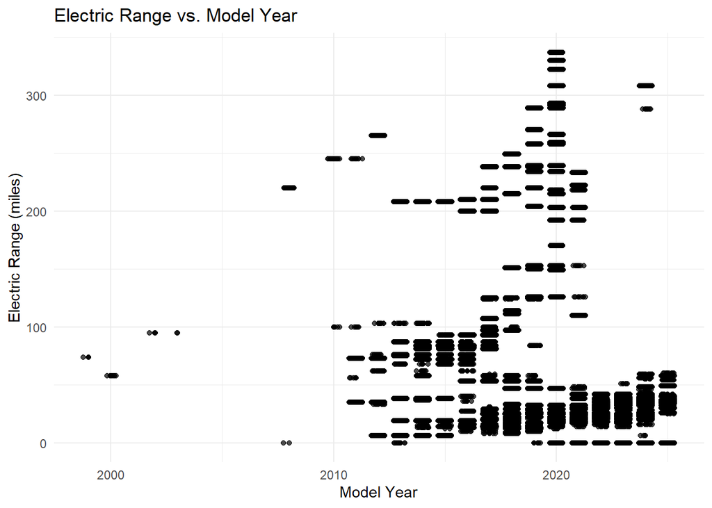

Without 0

```r
cc <- cor(no.zeros$Model.Year, no.zeros$Electric.Range)

print(cc)
```

```
## [1] -0.17499
```

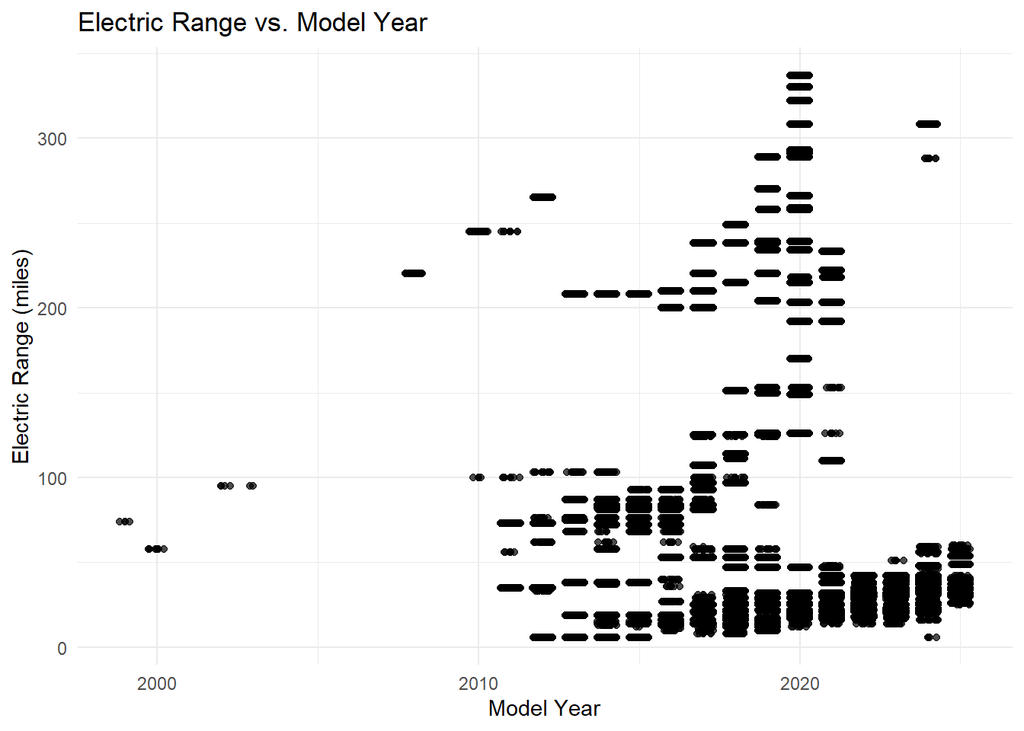

Well, the correlation coefficient kinda disproves my earlier statement, but only on a small scale.

## C.

### Frequency

| Make | Frequency |
| --- | --- |
| TESLA | 96180 |
| CHEVROLET | 16405 |
| NISSAN | 15259 |
| FORD | 11930 |
| KIA | 10760 |
| BMW | 9171 |
| TOYOTA | 8956 |
| HYUNDAI | 6878 |
| RIVIAN | 6236 |
| JEEP | 5773 |

The most frequent make of electric vehicle is Tesla. These are the top 10.

### Relative Frequency

| Make | Relative.Frequency |
| --- | --- |
| TESLA | 0.4293846 |
| CHEVROLET | 0.0732382 |
| NISSAN | 0.0681221 |
| FORD | 0.0532601 |
| KIA | 0.0480368 |
| BMW | 0.0409429 |
| TOYOTA | 0.0399830 |
| HYUNDAI | 0.0307060 |
| RIVIAN | 0.0278399 |
| JEEP | 0.0257729 |
| VOLKSWAGEN | 0.0256256 |
| VOLVO | 0.0248443 |
| AUDI | 0.0185584 |
| CHRYSLER | 0.0166656 |
| MERCEDES-BENZ | 0.0099958 |
| SUBARU | 0.0081698 |
| HONDA | 0.0080448 |
| PORSCHE | 0.0061475 |
| POLESTAR | 0.0054555 |
| MINI | 0.0048439 |
| MITSUBISHI | 0.0047546 |
| CADILLAC | 0.0045849 |
| MAZDA | 0.0040849 |
| LEXUS | 0.0038483 |
| FIAT | 0.0033840 |
| DODGE | 0.0032724 |
| LUCID | 0.0015938 |
| LINCOLN | 0.0015000 |
| GENESIS | 0.0014241 |
| GMC | 0.0013482 |
| SMART | 0.0010804 |
| JAGUAR | 0.0010402 |
| FISKER | 0.0008304 |
| ACURA | 0.0006295 |
| LAND ROVER | 0.0004464 |
| ALFA ROMEO | 0.0004063 |
| TH!NK | 0.0000223 |
| AZURE DYNAMICS | 0.0000179 |
| BENTLEY | 0.0000179 |
| BRIGHTDROP | 0.0000134 |
| ROLLS-ROYCE | 0.0000134 |
| WHEEGO ELECTRIC CARS | 0.0000134 |
| LAMBORGHINI | 0.0000089 |
| MULLEN AUTOMOTIVE INC. | 0.0000089 |
| RAM | 0.0000089 |
| VINFAST | 0.0000089 |

The difference between the first and second car is about 80000, so it makes sense that the relative frequency has such a big difference between them.

## D.

| Make | Electric Vehicle Type | Frequency | Relative_Frequency |
| --- | --- | --- | --- |
| TESLA | Battery Electric Vehicle (BEV) | 96180 | 0.4293846 |
| NISSAN | Battery Electric Vehicle (BEV) | 15259 | 0.0681221 |
| CHEVROLET | Battery Electric Vehicle (BEV) | 11685 | 0.0521663 |
| FORD | Battery Electric Vehicle (BEV) | 8234 | 0.0367597 |
| TOYOTA | Plug-in Hybrid Electric Vehicle (PHEV) | 7730 | 0.0345097 |
| KIA | Battery Electric Vehicle (BEV) | 7688 | 0.0343222 |
| RIVIAN | Battery Electric Vehicle (BEV) | 6236 | 0.0278399 |
| HYUNDAI | Battery Electric Vehicle (BEV) | 5883 | 0.0262640 |
| JEEP | Plug-in Hybrid Electric Vehicle (PHEV) | 5773 | 0.0257729 |
| VOLKSWAGEN | Battery Electric Vehicle (BEV) | 5740 | 0.0256256 |
| BMW | Plug-in Hybrid Electric Vehicle (PHEV) | 5567 | 0.0248532 |
| CHEVROLET | Plug-in Hybrid Electric Vehicle (PHEV) | 4720 | 0.0210719 |
| VOLVO | Plug-in Hybrid Electric Vehicle (PHEV) | 3751 | 0.0167459 |
| CHRYSLER | Plug-in Hybrid Electric Vehicle (PHEV) | 3733 | 0.0166656 |
| FORD | Plug-in Hybrid Electric Vehicle (PHEV) | 3696 | 0.0165004 |
| BMW | Battery Electric Vehicle (BEV) | 3604 | 0.0160896 |
| KIA | Plug-in Hybrid Electric Vehicle (PHEV) | 3072 | 0.0137146 |
| AUDI | Battery Electric Vehicle (BEV) | 2375 | 0.0106029 |
| VOLVO | Battery Electric Vehicle (BEV) | 1814 | 0.0080984 |
| AUDI | Plug-in Hybrid Electric Vehicle (PHEV) | 1782 | 0.0079555 |
| SUBARU | Battery Electric Vehicle (BEV) | 1737 | 0.0077546 |
| MERCEDES-BENZ | Battery Electric Vehicle (BEV) | 1708 | 0.0076252 |
| TOYOTA | Battery Electric Vehicle (BEV) | 1226 | 0.0054733 |
| POLESTAR | Battery Electric Vehicle (BEV) | 1222 | 0.0054555 |
| MITSUBISHI | Plug-in Hybrid Electric Vehicle (PHEV) | 1013 | 0.0045224 |
| HYUNDAI | Plug-in Hybrid Electric Vehicle (PHEV) | 995 | 0.0044421 |
| CADILLAC | Battery Electric Vehicle (BEV) | 940 | 0.0041965 |
| HONDA | Battery Electric Vehicle (BEV) | 939 | 0.0041921 |
| MAZDA | Plug-in Hybrid Electric Vehicle (PHEV) | 903 | 0.0040313 |
| MINI | Battery Electric Vehicle (BEV) | 863 | 0.0038528 |

[output cut: 62 more lines]

The cars are divided into their respective types, and the the frequency and relative frequency is given. Some of the proportions that are here are that there are more battery electric vehicles than plug-in or hybrids.

## E.

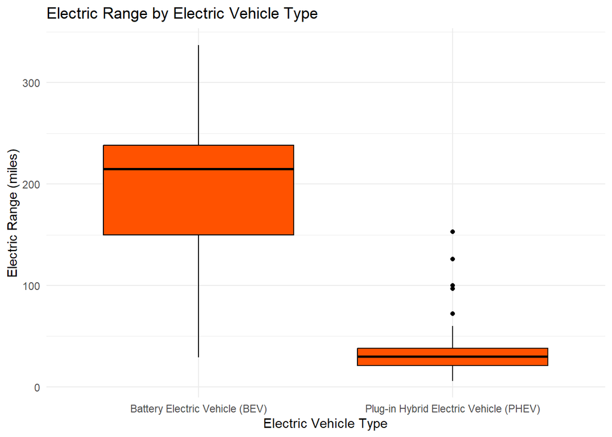

The boxplot shows the difference between BEV and PHEV, and just by looking at it the BEV category have a naturally higher range.

```r
ss <- no.zeros |>
  group_by(Electric.Vehicle.Type) |>
  summarise(
    Mean = mean(Electric.Range),
    SD = sd(Electric.Range),
    Median = median(Electric.Range),
    IQR = IQR(Electric.Range),
    Min = min(Electric.Range),
    Max = max(Electric.Range)
  )

kable(ss)
```

| Electric.Vehicle.Type | Mean | SD | Median | IQR | Min | Max |
| --- | --- | --- | --- | --- | --- | --- |
| Battery Electric Vehicle (BEV) | 197.69417 | 72.72783 | 215 | 88 | 29 | 337 |
| Plug-in Hybrid Electric Vehicle (PHEV) | 31.13038 | 14.73202 | 30 | 17 | 6 | 153 |

The summary statistics prove the previous statement by showing the math behind it.

## F.

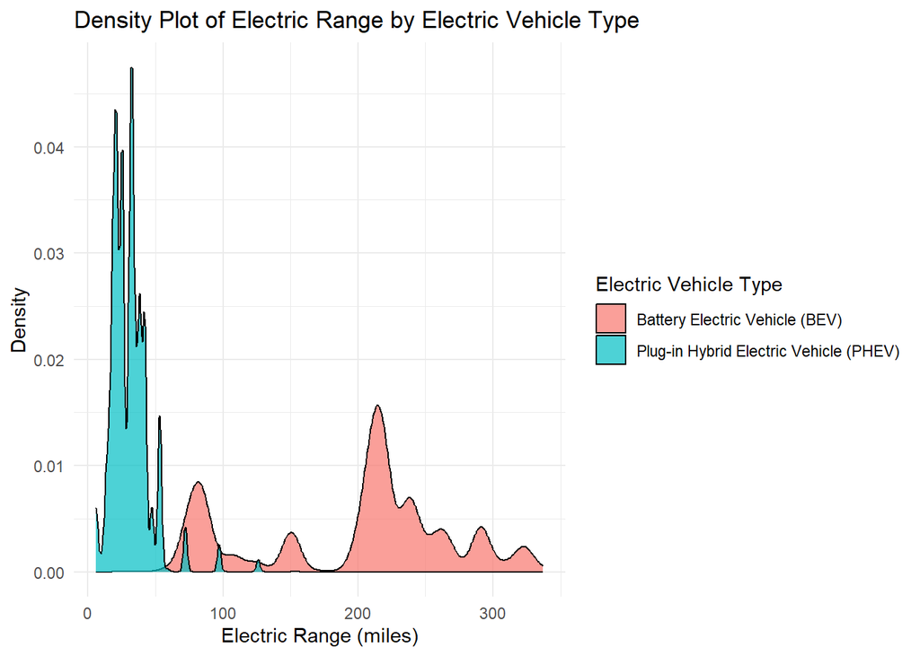

```r
ggplot(no.zeros, aes(x = Electric.Range, fill = Electric.Vehicle.Type)) +
  geom_density(alpha = 0.7) +
  labs(title = "Density Plot of Electric Range by Electric Vehicle Type",
       x = "Electric Range (miles)",
       y = "Density",
       fill = "Electric Vehicle Type") +
  theme_minimal()
```

The density plot shows that it is more common for there to be Plug-in Hybrids that range between 0 and 50 miles, and for Battery vehicles to be more spread about, with the majority of them having a range of a little over 200 miles.

# 3.

The dataset that I found is the Electric Car Population in the State of Washington. I found it on data.gov, after searching through several pages of data. I mostly used the type of car, make, model, and electric ranges for the questions. I did have to modify the data just a little, because NA’s are not in this document, and they replaced them with 0 instead. I did test with both just to see the difference.

Link: https://catalog.data.gov/dataset/electric-vehicle-population-data